# A educação infantil de oferta municipal em São Paulo

Cristiane Capuchinho e Anderson Henrique

2026-09-15

# 1. Apresentação

A educação infantil foi reconhecida como direito da criança e dever do Estado na Constituição Federal (Brasil, 1988). Entretanto, o acesso equânime de crianças de 0 a 5 anos a essa etapa e seu financiamento pelos municípios seguem um importante desafio.

Integrada como primeira etapa da educação básica na Lei de Diretrizes e Bases da Educação Nacional (Brasil, 1996), a educação infantil só passou a fazer parte do ensino obrigatório em 2009 com a expansão da faixa etária de obrigatoriedade para 4 anos, isto é, incluindo a pré-escola. A mudança constitucional criou uma cisão na etapa, com a pré-escola podendo acessar recursos vinculados à Manutenção e Desenvolvimento do Ensino (MDE) com prioridade em detrimento da creche.

Por outro lado, a inclusão das matrículas das duas fases da educação infantil no Fundeb (Brasil, 2007), com possibilidade de financiamento por recursos públicos de vagas diretas ou conveniadas com instituições sem fins lucrativos abriu uma via para ampliação da oferta de creche e pré-escola pelas redes municipais (Arelaro, 2017; Oliveira, 2013).

Os municípios enfrentam pressões simultâneas para ampliar a oferta de educação infantil e a jornada escolar. De um lado, a obrigatoriedade da pré-escola e as metas do Plano Nacional de Educação impulsionam a expansão do atendimento, incluindo a previsão de alcançar 60% das crianças de 0 a 3 anos na creche até 2036. De outro, a meta de ampliação da educação em tempo integral impulsiona uma demanda sobre os sistemas municipais. Assim, o desafio não é apenas o de ampliar a oferta, mas decidir como fazê-lo: o gasto varia segundo a etapa e a idade das crianças, o tipo de provisão — direta ou conveniada — e a duração da jornada.

A aprovação do Fundeb Permanente, em 2020, acrescentou uma nova dimensão a esse problema ao alterar as regras de financiamento, com o aumento progressivo da complementação da União e mudanças nos mecanismos de redistribuição.

Nesse contexto, compreender como os recursos disponíveis se traduzem em diferentes padrões de oferta e de gasto torna-se questão central.

## 1.1 Pergunta de pesquisa e objetivos

A pesquisa parte da seguinte pergunta: como o município de São Paulo ofertou e financiou a expansão da educação infantil entre 2016 e 2025? Para respondê-la, o estudo articula quatro dimensões: oferta, formas de provisão, jornada e financiamento, considerando tanto creche quanto pré-escola.

O estudo tem, para tanto, quatro objetivos específicos. O primeiro busca analisar a evolução da oferta de educação infantil no município de São Paulo, considerando as mudanças nas matrículas de creche e pré-escola, os diferentes tipos de provisão — rede direta ou indireta — e as jornadas parcial e integral. O segundo consiste em analisar a evolução e a estrutura do gasto público municipal, examinando sua distribuição entre subfunções, grupos de natureza e elemento de despesa. O terceiro objetivo é identificar e analisar a evolução das fontes de financiamento da educação infantil, com atenção às mudanças decorrentes da transição do Fundeb para o Fundeb Permanente e às alterações no Salário-Educação. Por fim, o quarto objetivo busca mapear as desigualdades territoriais na oferta de educação infantil, examinando como as matrículas e as diferentes formas de provisão e jornada se distribuem entre os distritos do município.

# 2. Metodologia

A pesquisa analisa a evolução da oferta e do gasto público com Educação Infantil no município de São Paulo entre 2016 e 2025, articulando dados de execução orçamentária da prefeitura de São Paulo (PMSP), dados de receita de bases nacionais e informações de matrículas do Censo Escolar (Inep). A análise tem como unidades de observação o ano e, em uma etapa específica, os distritos municipais.

Os dados de receita municipal de 2016 a 2024 foram obtidos na base disponibilizada pelo Ipea, que harmoniza informações provenientes de diferentes fontes, entre elas Siope, Finbra, STN e FNDE (Bridi et al., 2026). Os dados de execução da despesa municipal foram obtidos no portal da Secretaria Municipal de Planejamento e Eficiência da PMSP, com acesso em abril de 2026. Foram utilizados os valores liquidados, por representarem o estágio em que a despesa é reconhecida como obrigação, evitando tanto a incerteza associada aos valores empenhados quanto a distância temporal que pode existir entre a prestação do serviço e o pagamento. Receitas e despesas foram corrigidas pelo IPCA, tendo dezembro de 2025 como período de referência.

As despesas com educação infantil foram identificadas a partir dos projetos e atividades orçamentários relacionados à oferta da etapa, e não apenas da classificação pela subfunção Educação Infantil. Os projetos e atividades foram agrupados em componentes de gasto associados à oferta de matrículas em creche e pré-escola, como remuneração de profissionais, manutenção e operação das unidades, transferências, materiais, uniformes, transporte e investimentos. Esses componentes foram relacionados a categorias de matrícula segundo fase (creche ou pré-escola), tipo de provisão (rede direta ou indireta) e jornada (parcial ou integral).

A partir dessa correspondência, foram estimados valores de gasto por matrícula e aplicados às matrículas observadas em cada ano e distrito, permitindo calcular o gasto total e o gasto médio por matrícula de Educação Infantil. Para os componentes que abrangem jornadas de diferentes durações, as matrículas foram ponderadas de modo a atribuir peso 1 à jornada parcial e peso 2 à jornada integral. A metodologia detalhada de identificação, classificação e atribuição dos gastos, bem como os procedimentos de cálculo das matrículas e de validação das estimativas, está descrita no Apêndice Metodológico.

Para a análise da oferta, são consideradas tanto as matrículas da rede municipal direta quanto aquelas realizadas em instituições privadas parceiras do poder público. Foram incluídas as instituições que declararam parceria com a rede municipal, inclusive aquelas que também mantinham parceria com a rede estadual, em consonância com a responsabilidade prioritária dos municípios pela oferta de educação infantil.

Como dados contextuais, foram usadas informações de população e taxa de cobertura em creche e pré-escola retirados do Censo do IBGE (2022) e da Pnad Contínua.

Para a criação de uma proxy de vulnerabilidade econômica das crianças na Primeira Infância, foram usados dados da PMSP sobre o percentual de beneficiários do Bolsa Família entre os estudantes matriculados na educação infantil por distrito municipal. Para isso, os 96 distritos foram ordenados pelo percentual de alunos beneficiários do Bolsa Família entre as matrículas de oferta municipal e agrupados em vintis (20 grupos) ponderados pela matrícula de EI municipal de cada distrito (e não pelo número de distritos), do grupo dos 5% menos vulneráveis, o vintil V1, ao grupo dos 5% mais vulneráveis, o vintil V20.

O tratamento e processamento das bases foram realizados em R, incluindo procedimentos de transformação, agregação, integração e verificação de consistência. Ferramentas de inteligência artificial generativa, especificamente GPT-5 e Claude Sonnet 5, foram utilizadas como apoio à programação e à organização do processamento dos dados.

# 3. A educação infantil em São Paulo

## 3.1 Evolução da oferta pela rede municipal

O município de São Paulo ofertou **516.301** matrículas na educação infantil em 2025, isso representa **52,22%** do total de matrículas da educação básica oferecidas pela rede municipal. Desse total, **310.252** eram matrículas na creche para crianças de 0 a 3 anos e **206.049** eram vagas de pré-escola, matrículas de crianças de 4 e 5 anos.

Este é o resultado da trajetória da oferta de educação para a primeira infância, em especial, para a creche, já que entre 2016 e 2025, foram criadas **37.292** vagas em creche na capital paulista e, no mesmo período, as vagas em pré-escola tiveram redução de **7.448**.

O gráfico a seguir mostra, de 2016 a 2025, a evolução das taxas de cobertura de creche e pré-escola registradas na Pnad Contínua, que consideram a frequência das crianças à educação, seja ela custeada pelo Estado seja pelas famílias.

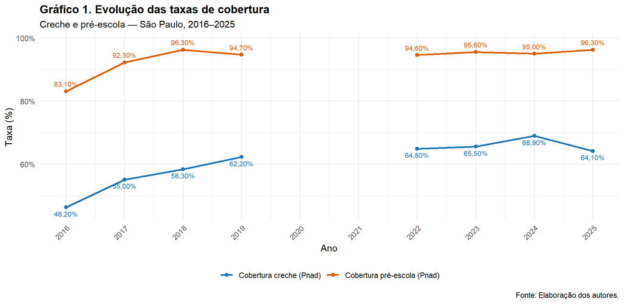

## 3.2 Provisão

A oferta de pré-escola, de ensino obrigatório, e de creche, etapa não obrigatória, tem características distintas na capital. Enquanto a pré-escola é oferecida majoritariamente na rede direta **(88,76%, em 2025)**, a creche tem **84,55%, em 2025** de suas matrículas em unidades conveniadas com o poder público.

Apesar das tendências seguirem as mesmas no período analisado, o cenário atual mostra uma ampliação da contratação de matrículas para alunos na rede conveniada em detrimento do aumento de matrículas na rede direta, tanto na creche quanto na pré-escola. Em 2016, a rede direta ofertava **56.751** vagas na creche. Uma década mais tarde, a rede direta é responsável por **47.949**.

Quando a análise é feita sobre a pré-escola, em 2016, a rede direta contava **206.502** vagas. Em 2025, a rede direta contava **182.882** crianças de 4 e 5 anos na educação infantil.

Por outro lado, em 2016, a rede indireta ofertava **216.209** vagas na creche. Em 2025, a soma de alunos em creches da rede parceira mostrava aumento de **46.094** em dez anos. Já na pré-escola, em 2016, a rede indireta contava apenas **6.995** matrículas. Em 2025, as unidades parceiras respondiam por **23.167** matrículas de crianças de 4 e 5 anos, aumento de **231,19%**.

## 3.3 Jornada

A **jornada integral é o padrão na oferta de vagas públicas em creche** na cidade de São Paulo, tanto na rede direta como na rede parceira. Em números de 2025, eram 47.949 matrículas em tempo integral na rede direta e 262.296 vagas de tempo integral na rede indireta. Havia apenas 7 vagas em creche de tempo parcial, uma opção de jornada oferecida aos pais no momento da matrícula.

Já na **pré-escola, a vaga pública de tempo parcial é o tipo de jornada mais comum** na rede. Eram 164.118 matrículas em tempo parcial na rede direta em 2025, o equivalente a **79,65% das matrículas** nessa fase da educação infantil.

Apenas **20,35% das matrículas estão no tempo integral**, isto é, 41.931 do total, sendo a maior parte em unidades da rede conveniada (23.167), como mostra o Gráfico 2.

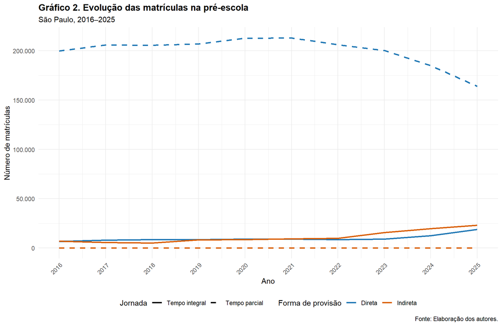

A distribuição dessas vagas de jornada integral para crianças entre 4 e 5 anos, nessa fase de preparação para a alfabetização, não são distribuídas igualmente no território da cidade. O mapa 1 mostra, para cada distrito, a proporção das matrículas de pré-escola (rede direta e indireta) ofertadas em tempo integral, em 2025.

Em 2025, **10 distritos tinham todas as suas matrículas de pré-escola da rede municipal em tempo integral**, sejam elas em unidades diretas ou indiretas: Barra Funda, Itaim Bibi, Jardim Paulista, Lapa, Liberdade, Marsilac, Moema, Perdizes, Pinheiros, e República.

Na outra ponta, **os cinco distritos com menor proporção de matrículas de pré-escola em tempo integral são Cidade Dutra (0,00%), Morumbi (0,00%), Santana (0,00%), Jaguaré (0,73%), e Campo Limpo (2,47%)**.

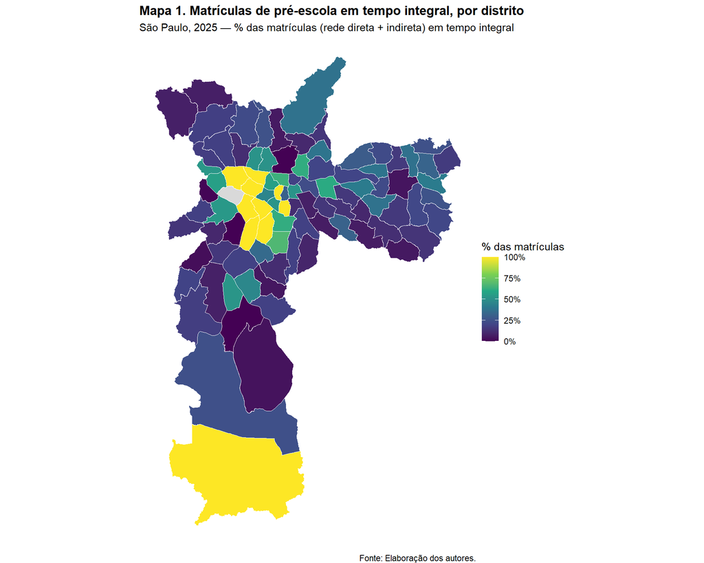

Outra forma de olhar a desigualdade na distribuição das vagas de tempo integral é verificar sua distribuição em relação aos grupos com maior número de beneficiários do Bolsa Família.

No grupo **V1**, formado pelos distritos com menor percentual de beneficiários do Bolsa Família na Educação Infantil[^1], **50,04%** das matrículas de pré-escola de oferta municipal estavam em tempo integral, em 2025. Já no grupo **V20**, formado pelos distritos com maior percentual de beneficiários do Bolsa Família na Educação Infantil, essa proporção foi de **19,49%**.

## 3.4 Proporção docentes por turma

As unidades da rede direta têm em média maior proporção de docentes por turma que a rede conveniada. Isso ocorre tanto na creche quanto na pré-escola.

Enquanto nas creches conveniadas a média de docentes por turma é de **1,01**, nas creches da rede municipal direta a proporção é de **2,00**, praticamente o dobro.

Na pré-escola o mesmo fenômeno se repete. A média de docente por turma de pré-escola conveniada é de **1,06**, diante da média de **1,42** em escolas da rede municipal direta. É importante destacar aqui que a rede parceira tem média menor de docentes por turma que a rede direta, apesar de concentrar as vagas de tempo integral nessa fase da educação infantil. Em 2025, **100,00%** das matrículas de pré-escola da rede indireta eram de tempo integral, enquanto na rede direta esse percentual era de **10,26%**.

Para entender se essa proporção melhorou ou piorou ao longo do tempo, vale comparar com 2016. Naquele ano, a média de docentes por turma nas creches da rede direta era de **1,98** e nas creches da rede indireta, de **0,99**. Na pré-escola, a média era de **1,33** docentes por turma na rede direta e de **1,03** na rede indireta.

## 3.5 Qualidade da infraestrutura

A infraestrutura é compreendida na literatura (Falciano; Santos; Nunes, 2016; Oliveira, 2016), e em documentos do Ministério da Educação (Brasil, 2015), como elemento de grande importância para determinar a qualidade da oferta na educação infantil. Dentre os itens mapeados anualmente pelo Censo Escolar, selecionamos quatro elementos da infraestrutura relacionados especificamente com educação infantil ou apontados como importantes para esta fase.

Foram eles: **presença de área verde** na unidade escolar, existência de **banheiro infantil**, disponibilidade de **jogos pedagógicos** e de **material de atividades artísticas**. A partir disso, foram criadas duas categorias de unidades para casos extremos, aquelas sem nenhum dos quatro itens e aquelas com todos os quatro itens. Todas essas informações estão presentes a partir do Censo Escolar de 2019.

O gráfico 3 evidencia a **maior presença de elementos identificados com a qualidade em unidades escolares da rede direta, tanto em 2019 quanto em 2025**. A maior distância pode ser percebida no percentual de matrículas da rede direta em unidades com área verde (40,17%, em 2025), diante de 23,91% de matrículas na rede parceira em unidades com área verde.

Ao comparar a evolução, percebe-se que, em unidades da rede direta, entre 2019 e 2025 houve aumento do percentual de matrículas ofertadas em unidades com cada um dos elementos investigados ou com a presença de todos, indicando a melhora na infraestrutura ofertada para essas unidades.

Já na rede indireta, no período analisado, há melhora apenas no índice de crianças matriculadas em unidades com material artístico (de 35,18% para 37,18%). E **entre as parceiras, há retração no percentual de matrículas em unidades indiretas com área verde, banheiro infantil, jogos pedagógicos ou todos os itens**. Chama a atenção que 22,81% das matrículas da rede indireta em 2025 estavam em unidades que não declararam possuir nenhum dos quatro itens no Censo Escolar.

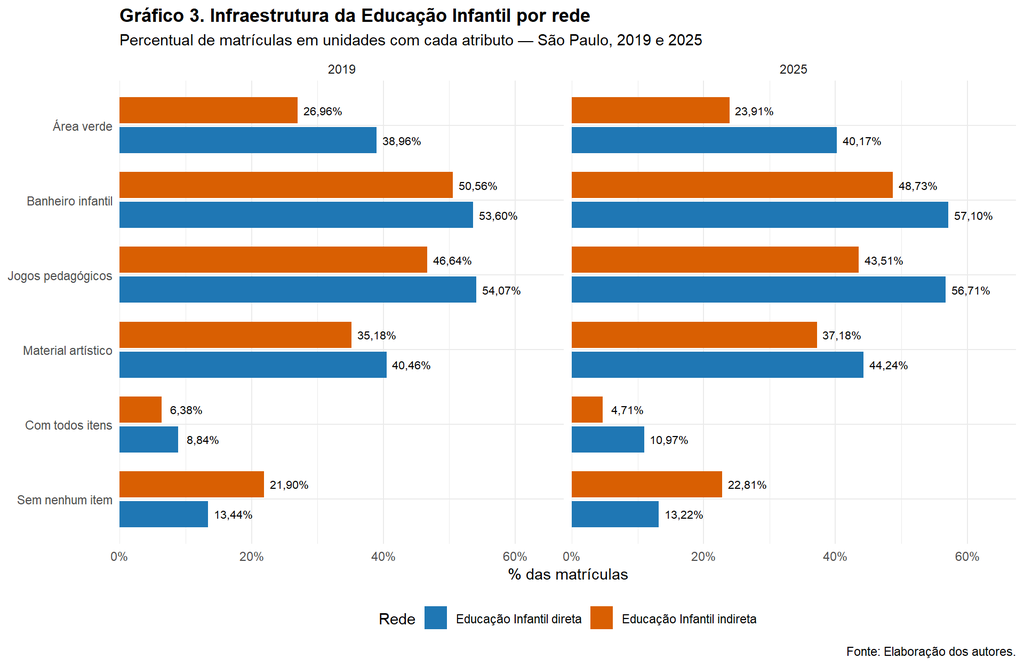

A análise por distritos (mapa 2) da proporção das matrículas de educação infantil (rede direta e indireta) ofertadas em unidades que reúnem todos os itens de infraestrutura considerados (área verde, banheiro infantil, jogos pedagógicos e material artístico), em 2025, indica que **31 distritos não apresentaram em 2025 qualquer unidade com matrículas de oferta municipal com os quatro itens de infraestrutura**, entre eles República, Liberdade, Marsilac, Barra Funda e Pinheiros.

Enquanto isso, os distritos **Saúde (43,74%), Vila Mariana (42,08%), Bela Vista (39,11%), Santa Cecília (36,62%), e Vila Leopoldina (32,29%) reúnem os maiores percentuais de matrículas em unidades com infraestrutura completa**.

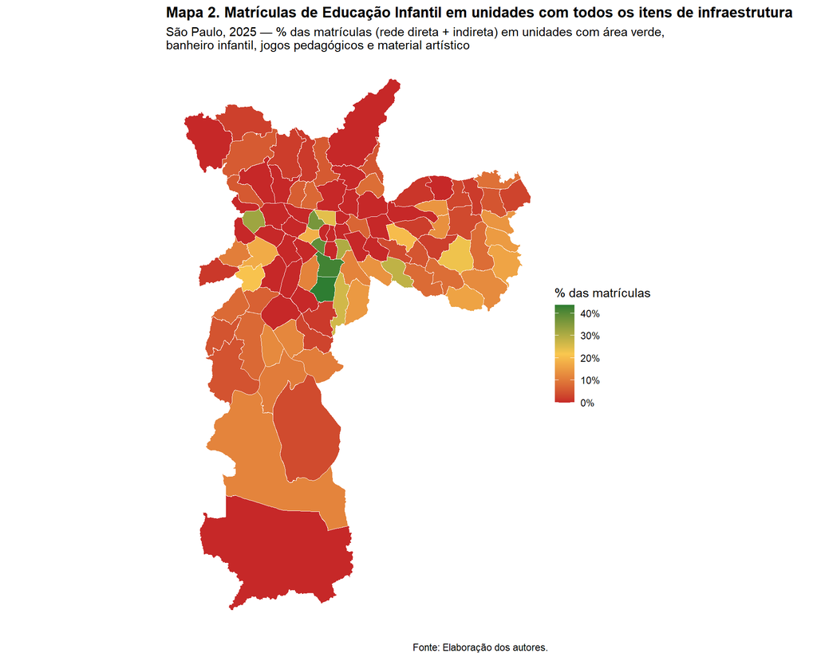

Relacionando a infraestrutura completa à proxy de vulnerabilidade econômica por vintis de distrito (ver Apêndice Metodológico), no grupo **V1** (distritos com menor percentual de beneficiários do Bolsa Família na Educação Infantil), **10,61%** das matrículas de Educação Infantil estavam em unidades com todos os quatro itens de infraestrutura, em 2025. Já no grupo **V20** (distritos com maior percentual de beneficiários), essa proporção foi de **14,69%**. Na média geral do município (São Paulo Toda), **7,51%** das matrículas de Educação Infantil estavam em unidades com infraestrutura completa.

A distribuição de vagas em unidades sem nenhum dos quatro itens de infraestrutura (mapa 3) aponta distritos em que a maioria das crianças estão em unidades com essas características, enquanto em 16 todas as crianças de 0 a 5 anos na estavam matriculadas em unidades com pelo menos um dos quatro itens considerados: Alto De Pinheiros, Bela Vista, Bom Retiro, Cambuci, Consolação, Itaim Bibi, Jardim Paulista, Liberdade, Moema, República, Sacomã, Santa Cecília, Socorro, Sé, Tatuapé, e Vila Mariana.

Já os cinco distritos com maior proporção de matrículas em unidades sem nenhum item de infraestrutura são Marsilac (69,42%), Brás (50,43%), Mandaqui (41,79%), Perdizes (41,43%), e Pinheiros (39,02%).

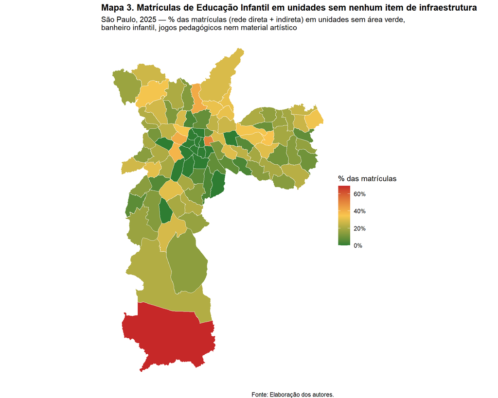

Relacionando a ausência de infraestrutura à mesma proxy de vulnerabilidade econômica por vintis de distrito, no grupo **V1** (distritos com menor percentual de beneficiários do Bolsa Família na Educação Infantil), **14,15%** das matrículas de Educação Infantil estavam em unidades sem nenhum item de infraestrutura, em 2025. Já no grupo **V20** (distritos com maior percentual de beneficiários), essa proporção foi de **16,25%**. Na média geral do município (São Paulo Toda), **18,53%** das matrículas de Educação Infantil estavam em unidades sem nenhum item de infraestrutura.

# 4. Evolução dos gastos em educação da PMSP

A ampliação da oferta de educação infantil e a expansão da jornada na pré-escola acontecem em um **período de aumento de gastos com educação no município de São Paulo. Entre 2016 e 2025, os recursos liquidados na Função Educação cresceram 77,1%**, já descontada a inflação no período (gráfico 4). Os valores passaram de R$ 15,4 bilhões, em 2016, para R$ 27,2 bilhões, em 2025. O crescimento é especialmente acelerado a partir de 2023.

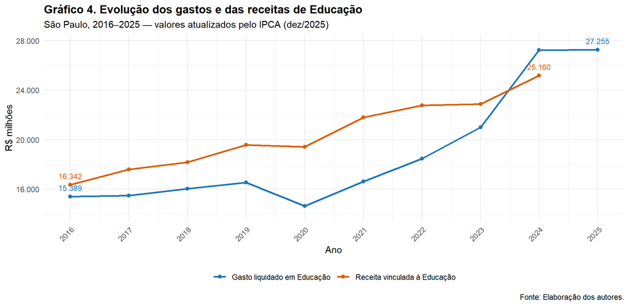

## 4.1 Fontes de receitas

Ao analisar as fontes dos recursos gastos em educação no município de São Paulo, revela-se que o gasto educacional na capital paulista é fortemente financiado pelo Tesouro Municipal, com menor relevância dos recursos redistribuídos pelo Fundeb.

São Paulo sustenta a maior parte de seus gastos educacionais com arrecadação própria, como mostra o gráfico 5. Em 2016, eram R$ 8,9 bilhões de gastos liquidados oriundos do Tesouro Municipal. Dez anos depois, o valor chegou a R$ 18,5 bilhões.

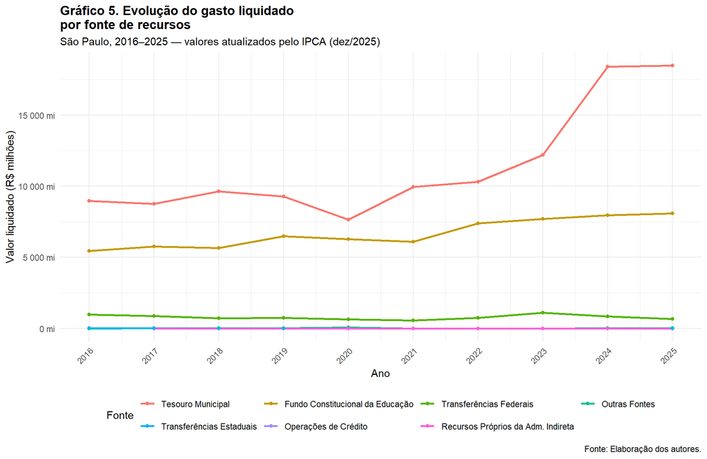

Já o Fundeb é fonte de cerca de um terço das despesas (tabela 2, no Apêndice de tabelas), valores entre R$ 5,4 bilhões, em 2016, e R$ 8,1 bilhões, em 2025. Essa baixa dependência do Fundeb segue, como aponta Nota Técnica de Pereira, Machado e Minarelli (2026), um padrão próprio de grandes cidades, com alta capacidade de financiamento por impostos próprios, como o IPTU e o ISS.

Ao longo do período, a terceira fonte de recursos são as transferências federais, que reúnem recursos do Salário-Educação e de transferências universais ou condicionadas do FNDE (Fundo Nacional de Desenvolvimento da Educação).

Considerando o período analisado, o valor médio anual das Transferências Federais foi de R$ 0,79 bilhões, indicando patamar bastante mais baixo dessa fonte na composição municipal.

## 4.2 Evolução de receitas do Fundeb

A participação do fundo constitucional Fundeb variou entre 42,92%, em 2020, e 29,23%, em 2024; com média no período de 36,25%. A participação expressiva de recursos próprios do município reduz o peso do Fundeb na composição do orçamento educacional e amplia a margem de decisão municipal sobre a alocação dos recursos vinculados à educação.

A implementação do Fundeb Permanente não alterou esse cenário. Embora tenha ampliado a complementação da União, São Paulo não recebe as modalidades destinadas à redução das desigualdades de financiamento, podendo acessar apenas a complementação VAAR, vinculada a resultados. E, em 2024, único ano que o município recebeu a complementação, esse recurso representou parcela pouco significativa do financiamento municipal (tabela 4, no Apêndice de tabelas).

É importante deixar claro que **os repasses do Fundeb, ligados diretamente ao número de matrículas ofertadas, tiveram crescimento ao longo do período mas em menor proporção em relação ao restante das outras fontes de receita**.

Vale destacar que, com as novas regras do Fundeb permanente, no ano de 2024 a capital recebe uma complementação federal graças às regras da complementação por resultado (VAAR). O montante da **complementação VAAR** recebida pelo município de São Paulo em 2024 é pequeno em relação ao valor geral. São **R$ 134,55 milhões**, o equivalente a **1,73%** de todo o recurso recebido.

## 4.3 Evolução de transferências federais

O salário-educação é a mais importante transferência federal recebida pelo município de São Paulo entre 2016 e 2025, representando mais de 75% das transferências desse tipo. Essa transferência merece ser analisada pela importante alteração institucional ocorrida em sua distribuição nesse período.

O salário-educação é uma contribuição social recolhida das empresas em âmbito federal e que são redistribuídos entre União, estados e municípios. Até 2023, a distribuição dessas cotas combinava a arrecadação de cada unidade da federação com o número de matrículas na educação básica da rede pública: primeiro, os recursos eram apropriados de acordo com a origem da arrecadação e, posteriormente, redistribuídos entre os municípios de cada estado segundo suas matrículas. Tal mecanismo fazia com que a capacidade de arrecadação de cada estado condicionasse o volume de recursos posteriormente disponível para seus municípios, produzindo diferenças expressivas na receita per capita do salário-educação entre as unidades da federação.

Essa forma de partilha foi alterada em decorrência de uma controvérsia jurídica iniciada em 2009 e encerrada pelo Supremo Tribunal Federal em 2022. A decisão determinou que, a partir de 2024, a totalidade das cotas destinadas a estados e municípios passasse a ser destinada conforme o número de matrículas na educação básica pública, conforme previsto pela Emenda Constitucional nº 53/2006. A mudança deslocou o critério de distribuição da origem estadual da arrecadação para uma lógica nacional baseada na matrícula, conferindo ao salário-educação maior caráter redistributivo (Bassi, 2023).

Para o município de São Paulo, a mudança implicou perda da vantagem relacionada à elevada arrecadação do estado de São Paulo (tabela 5, no Apêndice de tabelas). A mudança é observada nos dados de 2024, que indicam queda de **R$ 364,90 milhões** em relação ao ano anterior, o equivalente a uma queda de **44,89%**.

## 4.4 Evolução da participação da Educação Infantil nas despesas

Com quais etapas e modalidades da educação básica o município de São Paulo gasta? A análise das despesas liquidadas por subfunção permite identificar como os recursos da função Educação se distribuem entre diferentes áreas de atuação e, assim, observar mudanças nas prioridades de gasto do município. Nesta seção, a análise concentra-se no período de 2018 a 2025, quando a classificação orçamentária permite acompanhar de forma mais consistente a participação da Educação Infantil no conjunto das despesas educacionais. [^3]

Entre 2018 e 2025, o gasto liquidado com a subfunção Educação Infantil apresentou trajetória de crescimento: em valores atualizados, passou de **R$ 8,16 bilhões em 2018 para R$ 12,44 bilhões em 2025**, um aumento de aproximadamente 52,43%.

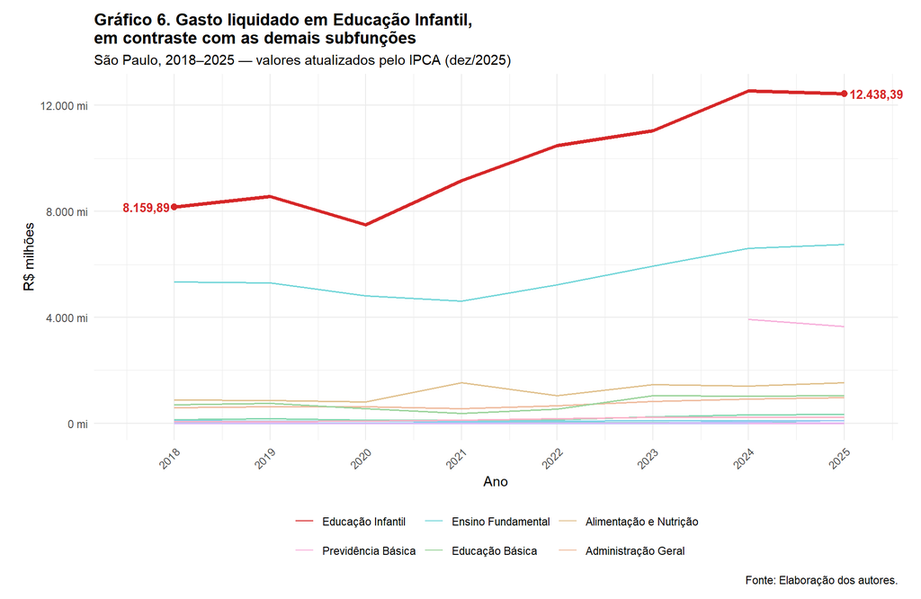

# 5. Em que o dinheiro é gasto?

Saber quanto o município gasta com educação infantil é apenas parte da história. A composição da despesa ajuda a entender como o município organiza a oferta dos serviços educacionais. A evolução dos gastos por natureza de despesa e por elemento revela, nesse sentido, mudanças importantes na estrutura da educação infantil paulistana.

## 5.1 Por grupo de natureza de despesa

Na função Educação, a composição do gasto mudou ao longo da última década. A participação de Pessoal e Encargos Sociais diminuiu gradualmente, enquanto Outras Despesas Correntes ganhou espaço.

Em 2016, os **gastos liquidados com Pessoal foram de R$ 8,49 bilhões**, o que representava **55,16%**. Em 2025, Pessoal tem liquidação de R$ **14,13 bilhões**, isto é, **51,84%** dos gastos por natureza de despesa na Função Educação naquele ano. A alteração é simultânea ao aumento gradativo da participação de matrículas de educação infantil via parceria com instituições privadas sem fins lucrativos, como apontado na terceira seção deste relatório.

A rede parceira se expande majoritariamente na educação infantil. Assim, uma lupa sobre os valores liquidados por natureza de despesas apenas na subfunção Educação Infantil, entre 2018 e 2025, mostra uma etapa em que Pessoal não aparece como principal gasto. Ao longo do tempo, apesar do gasto com pessoal crescer, ele passa a representar proporção cada vez menor das despesas. Isso porque dentro dessa categoria de natureza de despesa entram gastos apenas com o funcionalismo público.

Em 2025, o gasto com Pessoal e Encargos Sociais na subfunção Educação Infantil é de **R$ 4,64 bilhões**, representando **37,32%** do total de gastos por natureza de despesa na subfunção Educação Infantil. Outras Despesas Correntes, que incluem os gastos com a rede parceira, representam **61,55%** do total.

Isso não significa que na educação infantil paulistana a remuneração de profissionais é parcela com menor importância nas despesas. Isso é o registro de uma das consequências da escolha pela provisão indireta de serviços educacionais, que usa a contratação de pessoal de forma terceirizada, reduzindo assim o caráter pouco flexível do gasto com Pessoal em cargo público.

Outra categoria de despesa que pode ser observada pela natureza de despesa é o gasto com investimentos, isto é, com formação de capital. Ao longo de todo o período analisado, o percentual do gasto na subfunção Educação Infantil destinado a investimentos é baixo, não ultrapassando 1,23% do total em nenhum ano. Em 2018, foram liquidados R$ **65,14** milhões nesse grupo de natureza de despesa, o equivalente a **0,80%** do total da subfunção; em 2025, foram R$ **140,11** milhões, ou **1,13%**. A maior participação no período ocorreu em 2023, com R$ **135,94** milhões (**1,23%**), e a menor em 2022, com R$ **36,50** milhões (**0,35%**).

## 5.2 Gastos com pessoal na rede direta e indireta de EI

Aprofundando a análise ao elemento de despesa dos gastos liquidados na subfunção Educação Infantil, é possível ter mais elementos para entender diferenças entre provisão direta e indireta (tabela 7, no Apêndice de tabelas).

A primeira coisa é que para além dos gastos classificados como pessoal, a rede municipal custeia benefícios como **auxílio-transporte** e **auxílio-alimentação** que são registrados em outras despesas correntes. Esses benefícios somados equivalem a 8,5% dos gastos com remuneração em 2018 e 9,3%, em 2025. Ao somá-los aos gastos com o elemento Vencimentos e outras vantagens fixas, temos que o gasto com pessoal da educação infantil em 2018 foi de, ao menos, **R$ 4,20 bilhões**.

A comparação com o elemento “Outros serviços de terceiros - pessoa jurídica”, usado para registrar o pagamento de contratos terceirizados como as parcerias para creches e pré-escola, indica gasto 9,26% menor naquele ano com os contratos que com o pessoal da rede direta. O gasto com este elemento foi de **R$ 3,81 bilhões** em 2018. Os valores desses contratos englobam não apenas pagamento do pessoal da rede parceira, mas também manutenção, limpeza, locação do prédio e outros gastos para a oferta do serviço contratado.

Ao observar a evolução dos gastos por elemento no período, nota-se grande aumento dos valores registrados para contratação de serviços de terceiros - pessoa jurídica, avanço de 78,38%, na comparação entre 2025 e 2018. Isso muda o cenário.

Assim, em 2025, o gasto com **Outros serviços de terceiros - pessoa jurídica** chega a **R$ 6,80 bilhões** em 2025. Valor superior a soma dos três elementos de gasto com pessoal da rede direta (**R$ 5,08 bilhões, menor que o gasto com Outros serviços de terceiros - pessoa jurídica (R$ 6,80 bilhões)**).

A comparação tem limites. Não é possível saber qual parte do valor de cada ano é usado na contratação de oferta de vagas em creches e pré-escola. Nesse mesmo elemento, podem estar registrados gastos com segurança ou limpeza terceirizada em unidades diretas da educação infantil.

Até aqui, a análise identificou a magnitude dos gastos com educação infantil e sua composição, com alguns detalhes sobre a diferença entre provisão direta e indireta.

# 6. Estimativa de custeio por fase da educação infantil e jornada

Os gastos classificados na subfunção Educação Infantil não permitem diferenciar recursos usados para financiar a creche ou a pré-escola, sendo que apenas a última é obrigatória. Assim, usamos a classificação dos gastos por projeto atividade para recompor os gastos nas diferentes fases da educação infantil, por provisão direta ou parceira, e com jornadas diferentes (para detalhes, veja apêndice metodológico).

Para a rede direta, foi possível recompor gastos de remuneração, manutenção e custeio de unidades de creche a partir da classificação CEI (Centro de Educação Infantil), e para pré-escola a partir da classifição EMEI (Escola Municipal de Educação Infantil). Os valores de remuneração, manutenção e custeio de CEMEIs (Centro Municipal de Educação Infantil) foram divididos entre as matrículas das duas fases da educação infantil.

Para a rede indireta, os principais valores de custeio registram despesas com os contratos de parceiros, sem especificação de etapa de matrícula. Assim, os valores foram divididos entre as matrículas totais na rede parceira.

De 2018 a 2023, as despesas com compra de material escolar (benefício concedido a todos alunos da rede municipal) e compra de uniforme escolar (benefício concedido apenas aos alunos da educação obrigatória, ou seja, para a pré-escola) estão registradas de maneira conjunta. Assim, os valores foram divididos para o total de matrículas da educação infantil, causando uma sobrestimação para os gastos com creche.

Em 2024 e 2025, o gasto com uniforme escolar está registrado de forma separada e, assim, foi dividido apenas entre as matrículas de pré-escola de oferta direta ou indireta.

Gastos com transporte escolar foram divididos igualmente entre todas as matrículas da rede direta e indireta.

## 6.1 Limitações das estimativas

A reconstrução do gasto por matrícula a partir das ações orçamentárias apresenta limitações que devem ser consideradas na interpretação dos resultados. Na rede direta, os gastos com remuneração agregam despesas de profissionais com diferentes formações, remunerações e momentos da carreira, sem permitir identificar como esses gastos se distribuem entre unidades, distritos, etapas ou jornadas — a estimativa baseada em valores médios não captura, portanto, diferenças na composição do corpo docente.

Na rede indireta, a ação orçamentária que reúne os repasses para a manutenção da Educação Infantil não discrimina os diferentes arranjos de parceria (por exemplo, unidades em que o município arca com aluguel e unidades em imóveis cedidos), o que pode implicar gastos e condições de infraestrutura distintos não capturados pela estimativa. Os valores reconstruídos permitem, assim, comparar volume de gastos e sua distribuição entre diferentes tipos de oferta, mas não devem ser interpretados como medidas exatas do componente de gasto de cada matrícula.

A alimentação escolar não entrou no cômputo.

## 6.2 Evolução dos gastos por tipo de matrícula

Na creche em jornada integral, o valor estimado por matrícula na rede direta foi de **R$ 34.827** em 2018, contra **R$ 13.134** na rede indireta, uma diferença de **R$ 21.692 (165,2%)**. Em 2025, os valores foram de **R$ 53.176** e **R$ 21.863**, respectivamente, com diferença de **R$ 31.312 (143,2%)**.

Essa importante variação na despesa entre diferentes tipos de provisão deve ser lida junto com a composição do trabalho nas unidades (apresentada na seção 3). Em 2025, a creche da rede direta tinha, em média, **2,00 docentes por turma**, contra **1,01** na rede indireta.

Na comparação entre **pré-escola parcial na rede direta** e **pré-escola integral na rede indireta**[^4], o valor estimado por matrícula foi de **R$ 12.417** e **R$ 13.134**, respectivamente, em 2018, uma diferença de **R$ 717 (5,8%)**. Em 2025, os valores foram de **R$ 17.473** e **R$ 22.515**. Isso significa que a diferença entre custear uma matrícula de 4 horas na rede direta ou de 8 horas na rede indireta foi de **R$ 5.042 (28,9%)** em 2025.

Já a comparação entre **pré-escola integral na rede direta** e **pré-escola integral na rede indireta** mostra valores de **R$ 24.645** e **R$ 13.134**, respectivamente, em 2018, uma diferença de **R$ 11.510 (87,6%)**. Em 2025, os valores foram de **R$ 33.334** e **R$ 22.515**, com diferença de **R$ 10.820 (48,1%)**.

## 6.3 Investimentos em educação infantil

Os gastos não se limitam a custeio, o sistema de ensino precisa de constante investimento.

Os investimentos foram identificados a partir das ações orçamentárias de construção, ampliação, reforma e requalificação de unidades de educação infantil. Para observar sua evolução, os valores foram agregados por fase da educação infantil, distinguindo investimentos em creche e em pré-escola.

Vale destacar que os investimentos em construção, ampliação ou reforma de unidades não equivalem a investimento na rede direta. Um dos modelos de parceria na educação oferecida no município de São Paulo inclui o uso de prédios municipais.

Entre 2018 e 2025, os investimentos em creche passaram de **R$ 54,2 milhões** para **R$ 52,9 milhões**, enquanto os investimentos em pré-escola variaram de **R$ 5,4 milhões** para **R$ 86,3 milhões**. O maior valor anual registrado no período correspondeu à **Pré-escola**, em **2024**, com **R$ 89,3 milhões**.

## 6.4 Desigualdades territoriais no gasto por matrícula

A partir dos valores gastos por tipo de matrícula ofertada nos diferentes distritos de São Paulo, é possível estimar um valor médio de gasto por aluno da educação infantil por distrito e por ano. O objetivo é criar um indicador comparativo do esforço de gasto feito pela Prefeitura para custear a educação de crianças de 0 a 6 anos nos 96 territórios da cidade, dadas as diferentes decisões de provisão e de jornada.

Para isso, a fórmula usada foi: Valor médio por aluno do distrito = valor total de gasto com matrículas de EI no distrito no ano / total de matrículas de EI de oferta municipal no distrito no ano.

O gráfico 7 indica o menor e o maior gasto médio na educação infantil por distrito, sendo a diferença entre os dois a amplitude da desigualdade, que se mantém elevada ao longo dos anos. Em 2018, essa diferença era de 88%. Em 2025, o gasto por criança da educação infantil no distrito com maior valor foi 73% maior do que aquele do menor distrito.

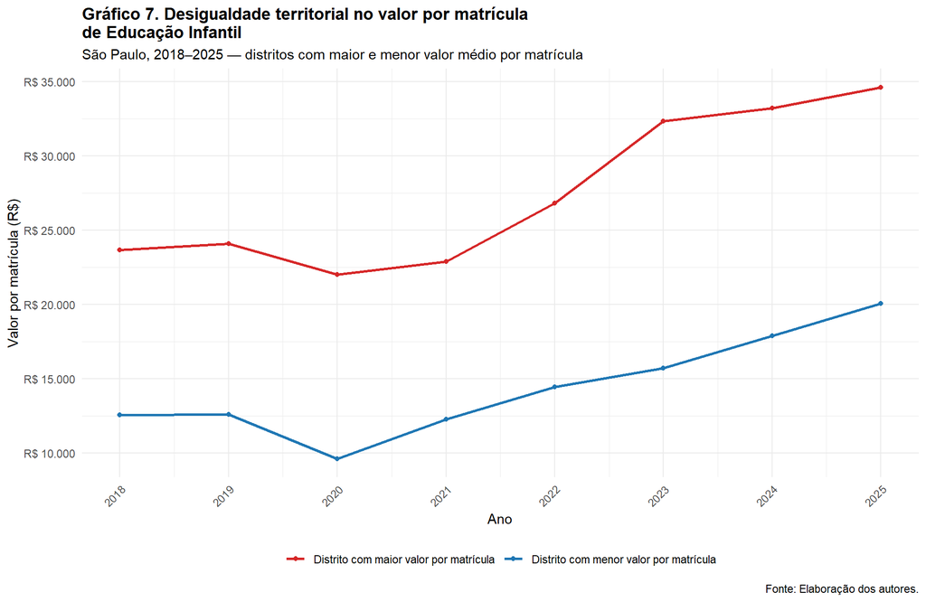

O mapa 4 localiza territorialmente essa desigualdade, mostrando, para cada um dos 96 distritos de São Paulo em 2025, o valor médio por matrícula de Educação Infantil como um índice em relação à média municipal (São Paulo = 1): valores acima de 1 indicam gasto por matrícula acima da média da cidade, e valores abaixo de 1, gasto abaixo da média.

Os cinco distritos com **maior valor médio por matrícula de Educação Infantil** em 2025 são Jardim Paulista, Pinheiros, Socorro, Lapa, e Moema.

Na outra ponta, os cinco **distritos com menor valor médio por matrícula** são Mooca, Santo Amaro, Pari, Belém, e Carrão.

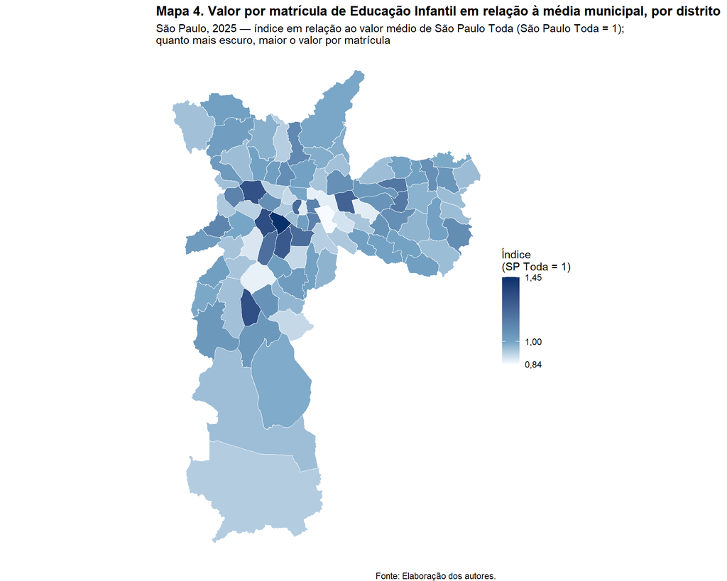

Os três distritos com **maior valor médio por matrícula de Educação Infantil em relação à média municipal** em 2025 são Jardim Paulista (índice de 1,45 e 9,4% de beneficiários do Bolsa Família), Pinheiros (índice de 1,33 e 11,7% de beneficiários do Bolsa Família), e Socorro (índice de 1,32 e 27,2% de beneficiários do Bolsa Família). Na outra ponta, os três com **menor índice** são Mooca (índice de 0,84 e 30,2% de beneficiários do Bolsa Família), Santo Amaro (índice de 0,86 e 25,5% de beneficiários do Bolsa Família), e Pari (índice de 0,86 e 36,4% de beneficiários do Bolsa Família). Em média, 16,1% das matrículas de Educação Infantil municipal nos três distritos de maior índice são de beneficiários do Bolsa Família, ante 30,7% nos três de menor índice.

# 7. Considerações finais

O estudo indica que na educação infantil, o município de São Paulo ainda tem um desafio importante na ampliação da jornada escolar na pré-escola, início da educação obrigatória e fase em que a criança adquire habilidades necessárias para a posterior alfabetização (Sealf - MEC, 2021). O município tem **79,65%** de suas matrículas nesta fase em tempo parcial.

Para a creche, o município conseguiu de maneira consistente ampliar as vagas em jornada integral em todo o território, apoiado amplamente no uso de parcerias com a rede privada. No entanto, os indicadores de docente por turma e de infraestrutura apontam condições mais precárias na rede parceira, que atende a maior parte das crianças de 0 a 3 anos.

O menor número de professores por criança e diferenças na remuneração são hipóteses para explicar a diferença nos valores gastos por matrícula na rede direta e indireta. Auditoria do TCM-SP apontou que os professores da rede parceira recebem salário entre 25% e 38% inferior em relação aos salários dos professores da rede direta, mesmo sem considerar vantagens pessoais e gratificações (TCMSP, 2026) . Além disso, enquanto a rede direta tem dois professores por turma de creche, a rede parceira tem um professor por turma. Essa realidade impacta diretamente no tempo para formação e produção de atividades desses docentes que, na rede direta, contam com 10 horas semanais (entre dois professores) fora de sala de aula e os da rede parceira que têm 4 horas semanais (TCMSP, 2026).

Ao olhar para o território, a diferença de valores por matrícula entre rede direta e indireta e o tipo de jornada são a chave para compreender as desigualdades.

Em relação à estrutura do financiamento, como esperado por seu porte e pujança econômica, o município de São Paulo tem o Tesouro Municipal como sua principal fonte de receita para os gastos em educação. Se o retrato não é novidade, essa estrutura de financiamento pode trazer desafios com a reforma orçamentária que vai integrar o ISS ao IBS a partir de 2029, sendo oficialmente extinto a partir de 2033. O ISS é a principal fonte de arrecadação do município.

As informações foram analisadas e validadas por Cristiane Capuchinho. As bases de dados foram organizadas e tratadas por Anderson Henrique e Cristiane Capuchinho.

# Apêndice de tabelas

Tabela 1. Gasto liquidado em Educação, receita vinculada à Educação e impostos adicionais vinculados ao MDE — São Paulo, 2016–2025 (R$ milhões, valores atualizados pelo IPCA a dezembro de 2025) Fonte: Elaboração dos autores.

| Ano | Gasto liquidado em Educação | Receita vinculada à Educação | Impostos adicionais vinculados ao MDE |
| --- | --- | --- | --- |
| 2016 | 15.389,12 | 16.342,15 | 9.376,76 |
| 2017 | 15.468,38 | 17.587,41 | 10.243,71 |
| 2018 | 16.039,01 | 18.185,38 | 10.618,67 |
| 2019 | 16.537,50 | 19.559,65 | 11.580,47 |
| 2020 | 14.647,85 | 19.402,63 | 11.599,55 |
| 2021 | 16.616,18 | 21.788,32 | 13.059,45 |
| 2022 | 18.457,54 | 22.778,62 | 13.488,07 |
| 2023 | 21.008,98 | 22.882,33 | 14.043,16 |
| 2024 | 27.224,08 | 25.159,97 | 15.925,39 |
| 2025 | 27.254,67 | NA | NA |

Tabela 2. Participação percentual de cada fonte de recursos no gasto liquidado em Educação, por ano — São Paulo, 2016–2025 Fonte: Elaboração dos autores.

| Fonte | 2016 | 2017 | 2018 | 2019 | 2020 | 2021 | 2022 | 2023 | 2024 | 2025 |
| --- | --- | --- | --- | --- | --- | --- | --- | --- | --- | --- |
| Tesouro Municipal | 58,26% | 56,70% | 60,03% | 56,05% | 52,29% | 59,94% | 55,89% | 58,09% | 67,64% | 67,80% |
| Fundo Constitucional da Educação | 35,35% | 37,26% | 35,34% | 39,29% | 42,92% | 36,62% | 40,11% | 36,68% | 29,23% | 29,69% |
| Transferências Federais | 6,33% | 5,72% | 4,51% | 4,55% | 4,37% | 3,44% | 4,00% | 5,21% | 3,09% | 2,42% |
| Outras Fontes | 0,00% | 0,16% | 0,07% | 0,11% | 0,42% | 0,00% | 0,00% | 0,02% | 0,03% | 0,08% |
| Transferências Estaduais | 0,07% | 0,16% | 0,04% | 0,00% | 0,00% | 0,00% | 0,00% | 0,00% | 0,00% | 0,00% |
| Operações de Crédito | 0,00% | 0,00% | 0,00% | 0,00% | 0,00% | 0,00% | 0,00% | 0,00% | 0,00% | 0,00% |
| Recursos Próprios da Adm. Indireta | 0,00% | 0,00% | 0,00% | 0,00% | 0,00% | 0,00% | 0,00% | 0,00% | 0,00% | 0,00% |

Tabela 3. Comparação da variação do gasto liquidado entre 2016 e 2025 — Fundo Constitucional da Educação versus demais fontes de recursos — São Paulo Fonte: Elaboração dos autores.

| Período | Variação — Fundo Constitucional da Educação | Variação — Demais fontes | Diferença (p.p.) |
| --- | --- | --- | --- |
| 2016–2025 | 48,76% | 92,60% | -43,85% |

Tabela 4. Composição da receita do Fundeb — São Paulo, 2016–2024 (R$ milhões, valores atualizados pelo IPCA a dezembro de 2025) Fonte: Elaboração dos autores.

| Ano | Transferências Fundeb | Complementação VAAR |
| --- | --- | --- |
| 2016 | 5.350,54 | 0,00 |
| 2017 | 5.683,53 | 0,00 |
| 2018 | 5.914,96 | 0,00 |
| 2019 | 6.458,84 | 0,00 |
| 2020 | 6.217,21 | 0,00 |
| 2021 | 7.075,55 | 0,00 |
| 2022 | 7.598,54 | 0,00 |
| 2023 | 7.071,23 | 0,00 |
| 2024 | 7.653,81 | 134,55 |

Tabela 5. Salário-Educação em relação à receita total vinculada à Educação — São Paulo, 2016–2024 (R$ milhões, valores atualizados pelo IPCA a dezembro de 2025) Fonte: Elaboração dos autores.

| Ano | Salário-Educação | Receita total vinculada à Educação | % Salário-Educação no total |
| --- | --- | --- | --- |
| 2016 | 684,07 | 16.342,15 | 4,19% |
| 2017 | 696,92 | 17.587,41 | 3,96% |
| 2018 | 710,95 | 18.185,38 | 3,91% |
| 2019 | 598,16 | 19.559,65 | 3,06% |
| 2020 | 691,92 | 19.402,63 | 3,57% |
| 2021 | 704,97 | 21.788,32 | 3,24% |
| 2022 | 784,64 | 22.778,62 | 3,44% |
| 2023 | 812,83 | 22.882,33 | 3,55% |
| 2024 | 447,93 | 25.159,97 | 1,78% |

Tabela 6. Gasto liquidado em Educação por subfunção e participação percentual no total do ano — São Paulo, 2018, 2022 e 2025 (valores em milhões de R$, atualizados pelo IPCA a dezembro de 2025) Fonte: Elaboração dos autores.

| Ds_SubFuncao | 2018 - % no ano | 2018 - R$, em milhões | 2022 - % no ano | 2022 - R$, em milhões | 2025 - % no ano | 2025 - R$, em milhões |
| --- | --- | --- | --- | --- | --- | --- |
| Educação Infantil | 50,88% | 8.159,89 | 56,78% | 10.480,88 | 45,64% | 12.438,39 |
| Ensino Fundamental | 33,31% | 5.342,28 | 28,33% | 5.228,61 | 24,79% | 6.756,15 |
| Alimentação e Nutrição | 5,51% | 884,36 | 5,66% | 1.044,58 | 5,65% | 1.540,18 |
| Previdência Básica | 0,00% | 0,00 | 0,00% | 0,00 | 13,40% | 3.651,28 |
| Educação Básica | 4,35% | 697,17 | 2,93% | 541,40 | 3,82% | 1.042,04 |
| Administração Geral | 3,75% | 601,03 | 3,67% | 677,60 | 3,60% | 981,91 |
| Educação Especial | 0,84% | 135,46 | 0,76% | 139,79 | 1,27% | 345,83 |
| Outras subfunções | 1,36% | 218,83 | 1,87% | 344,67 | 1,83% | 498,89 |

Tabela 7. Gasto liquidado por elemento de despesa na subfunção Educação Infantil e participação percentual no total do ano — São Paulo, 2018, 2022 e 2025 (valores em milhões de R$, atualizados pelo IPCA a dezembro de 2025) Fonte: Elaborado pelos autores a partir da Base de Dados de Execução Orçamentária da PMSP

| Elemento de despesa | 2018 em R$ | 2018 em % | 2022 em R$ | 2022 em % | 2025 em R$ | 2025 em % |
| --- | --- | --- | --- | --- | --- | --- |
| Outros serviços de terceiros - pessoa jurídica | 3.814,67 | 46,75% | 5.772,59 | 55,08% | 6.804,51 | 54,71% |
| Vencimentos e vantagens fixas - pessoal civil | 3.879,66 | 47,55% | 4.156,05 | 39,65% | 4.642,13 | 37,32% |
| Auxílio-alimentação | 315,64 | 3,87% | 366,20 | 3,49% | 429,31 | 3,45% |
| Material, bem ou serviço para distribuição gratuita | 4,28 | 0,05% | 19,88 | 0,19% | 316,98 | 2,55% |
| Outros serviços de terceiros - pessoa física | 53,46 | 0,66% | 75,45 | 0,72% | 83,51 | 0,67% |
| Obras e instalações | 49,46 | 0,61% | 25,71 | 0,25% | 115,33 | 0,93% |
| Outros auxílios financeiros a pessoas físicas | 0,00 | 0,00% | 39,82 | 0,38% | 0,00 | 0,00% |
| Aquisição de imóveis | 10,16 | 0,12% | 8,46 | 0,08% | 10,41 | 0,08% |
| Material de consumo | 11,36 | 0,14% | 4,64 | 0,04% | 9,33 | 0,08% |
| Despesas de exercícios anteriores | 4,80 | 0,06% | 0,90 | 0,01% | 16,65 | 0,13% |
| Auxílio-transporte | 8,75 | 0,11% | 5,38 | 0,05% | 4,50 | 0,04% |
| Obrigações tributárias e contributivas | 2,13 | 0,03% | 4,40 | 0,04% | 4,68 | 0,04% |
| Equipamentos e material permanente | 5,52 | 0,07% | 0,53 | 0,01% | 0,86 | 0,01% |
| Indenizações e restituições | 0,00 | 0,00% | 0,87 | 0,01% | 0,18 | 0,00% |
| Transferências por meio de contrato de gestão | 0,00 | 0,00% | 0,00 | 0,00% | 0,00 | 0,00% |

Tabela 8. Valor estimado por matrícula de Educação Infantil, por fase, tipo de provisão e jornada — São Paulo, 2018–2025 (R$, atualizados pelo IPCA a dezembro de 2025) Fonte: Elaboração dos autores.

| matricula | 2018 | 2019 | 2020 | 2021 | 2022 | 2023 | 2024 | 2025 |
| --- | --- | --- | --- | --- | --- | --- | --- | --- |
| Creche jornada integral — rede direta | 34.827 | 35.969 | 35.825 | 33.921 | 42.238 | 48.508 | 50.232 | 53.176 |
| Creche jornada integral — rede indireta | 13.134 | 13.277 | 9.602 | 15.378 | 17.306 | 17.327 | 21.585 | 21.863 |
| Creche jornada parcial — rede direta | 17.508 | 18.075 | 17.967 | 17.021 | 21.333 | 24.548 | 25.512 | 27.068 |
| Creche jornada parcial — rede indireta | 13.134 | 13.277 | 9.602 | 15.378 | 17.306 | 17.327 | 21.585 | 21.863 |
| Pré-escola jornada parcial — rede direta | 12.417 | 12.391 | 11.782 | 11.412 | 13.548 | 15.203 | 16.744 | 17.473 |
| Pré-escola jornada integral — rede direta | 24.645 | 24.600 | 23.454 | 22.701 | 26.669 | 29.817 | 32.194 | 33.334 |
| Pré-escola jornada integral — rede indireta | 13.134 | 13.277 | 9.602 | 15.378 | 17.306 | 17.327 | 22.087 | 22.515 |
| Pré-escola jornada parcial — rede indireta | 13.134 | 13.277 | 9.602 | 15.378 | 17.306 | 17.327 | 21.585 | 21.863 |

Tabela 9. Distritos com os 10 maiores e os 10 menores índices do valor médio por matrícula de Educação Infantil em relação à média municipal, e percentual de beneficiários do Bolsa Família na Educação Infantil municipal — São Paulo, 2025 Fonte: Elaboração dos autores.

| Distrito | Índice (SP Toda = 1) | % de beneficiários do Bolsa Família na EI municipal |
| --- | --- | --- |
| **10 maiores índices** |  |  |
| Jardim Paulista | 1,45 | 9,4% |
| Pinheiros | 1,33 | 11,7% |
| Socorro | 1,32 | 27,2% |
| Lapa | 1,31 | 20,4% |
| Moema | 1,28 | 13,7% |
| Tatuapé | 1,24 | 24,5% |
| República | 1,22 | 43,0% |
| Vila Mariana | 1,21 | 20,2% |
| Itaim Bibi | 1,20 | 22,1% |
| Ponte Rasa | 1,17 | 44,2% |
| **10 menores índices** |  |  |
| Mooca | 0,84 | 30,2% |
| Santo Amaro | 0,86 | 25,5% |
| Pari | 0,86 | 36,4% |
| Belém | 0,87 | 33,1% |
| Carrão | 0,87 | 30,2% |
| Sé | 0,87 | 48,4% |
| Morumbi | 0,88 | 38,1% |
| Água Rasa | 0,89 | 30,6% |
| Santa Cecília | 0,90 | 33,1% |
| Saúde | 0,90 | 19,1% |

# Apêndice Metodológico

## A1. Reconstrução de gastos por fase da educação infantil e tipo de provisão

Cada tipo de componente de gasto corresponde à agregação dos valores liquidados nas ações orçamentárias selecionadas para representá-lo, sendo que para a reconstituição estimada do valor gasto por tipo de matrícula será necessária a soma de diferentes componentes de gasto, como será apresentado mais à frente.

As ações por componente de gasto estão indicadas abaixo:

1. Componente de gasto por matrícula de educação infantil na rede indireta

   • 2828 — Manutenção e Operação da Rede Parceira - Centro de Educação Infantil (CEI) • 2825 — Operação e Manutenção de CEIs e Creches da rede conveniada e outras modalidades de parcerias
2. Componente de gasto por matrícula de creche na rede direta

   • 2856 — Remuneração dos Profissionais do Magistério - Centro de Educação Infantil (CEI) • 4360 — Manutenção e Operação de Centros de Educação Infantil (CEI)
3. Componente de gasto por matrícula de pré-escola na rede direta

   • 2858 — Remuneração dos Profissionais do Magistério - Escola Municipal de Educação Infantil (EMEI) • 4362 — Manutenção e Operação de Escolas Municipais de Educação Infantil (EMEI)
4. Componente de gasto por matrícula de educação infantil na rede direta

   • 2840 — Transferência de Recursos Financeiros para as Unidades Educacionais - Educação Infantil • 2877 — Remuneração dos Profissionais do Magistério - Centro Municipal de Educação Infantil (CEMEI) • 2876 — Manutenção e Operação de Centros Municipais de Educação Infantil (CEMEI) • 2878 — Conservação e Manutenção de Unidades Educacionais - Educação Infantil • 2824 — Manutenção e Operação de Unidades Educacionais - Educação Indígena
5. Componente de gasto por matrícula da rede EI de oferta municipal

   • 2815 — Fornecimento de Material Escolar - Educação Infantil
6. Componente de gasto por matrícula da pré-escola de oferta municipal

   • 2811 — Fornecimento de Uniformes - Educação Infantil
7. Investimento em rede direta de creche

   • 3359 — Construção de Centros de Educação Infantil - CEI • 3360 — Ampliação, Reforma e Requalificação de Centros de Educação Infantil (CEI)
8. Investimento em rede direta de pré-escola

   • 3362 — Ampliação, Reforma e Requalificação de EMEIs • 3361 — Construção de Escolas Municipais de Educação Infantil (EMEI) • 3358 — Construção de Escolas Municipais de Educação Infantil - EMEI
9. Transporte escolar - Educação Infantil

   • 2849 — Transporte Escolar - Educação Infantil

Destaca-se que não foram utilizados os recursos liquidados no Projeto Atividade “Bolsa Primeira Infância”, um programa criado em 2019 para atender crianças entre 0 e 3 anos que ainda não estavam matriculadas em creche. Para as famílias em situação de alta vulnerabilidade e já inscritas no CAD Único, a Prefeitura ofereceu um auxílio financeiro mensal de R$ 200. O benefício era emergencial, a ser suspenso no momento da disponibilização de vagas. O programa foi suspenso em 2021. O Projeto Atividade 2886 apresentou uma execução total de **R$ 7.409.105,49** no período analisado, que foram registrados como parte da subfunção Educação Infantil. Embora o programa estivesse relacionado à política de acesso à creche, seus recursos eram transferidos diretamente às famílias e não financiavam a oferta de vagas ou o funcionamento das unidades educacionais. Por esse motivo, foram excluídos da estimativa de gasto associado à oferta de Educação Infantil.

É preciso chamar a atenção para o fato de que os componentes de gasto não incluem gastos com alimentação escolar. Isso porque o registro reúne gastos de merenda escolar de todas as etapas de ensino e tipos de jornada, impossibilitando a ponderação desses gastos sem uma análise aprofundada da forma como são realizados os repasses e as ofertas de merenda em todas as etapas e modalidades ofertadas pela rede.

Essa reclassificação foi cotejada com os gastos registrados pela prefeitura na subfunção “Educação Infantil” e foram recompostos gastos equivalentes a entre 99,92% e 100% do gasto, conforme os diferentes anos. A diferença se dá pela escolha metodológica de não contabilizar recursos usados no projeto-atividade “Bolsa Primeira Infância”. O Programa Bolsa Primeira Infância, vigente entre 2019 e 2021, não entrou na recomposição de componentes de gasto por considerarmos que este programa de transferência de recursos para famílias na fila da creche não constitui gastos com oferta de educação infantil.

**Ponderação de matrículas em tempo integral e parcial**

Em relação aos diferentes tipos de jornada, os dados de execução de recursos municipais não possuem descritores que permitam separar gastos realizados com matrículas da educação infantil em tempo integral ou em tempo parcial. Ao olhar o país, uma das dificuldades é a heterogeneidade de períodos para matrículas de tempo integral.

A LDB prevê, desde 2013, que a educação infantil de tempo integral deve ter, no mínimo, 7 horas diárias. As matrículas parciais, por regra (Brasil, 1996), têm jornada de 4 horas diárias. Na rede municipal de São Paulo, o tempo integral em vagas de creche equivale a jornadas diárias de dez horas. Já na pré-escola, o tempo integral equivale a jornadas diárias de oito horas. A jornada parcial é, por sua vez, de quatro horas diárias.

E a partir de quais referências pensar o financiamento de jornadas diferentes? Os fatores de ponderação do Fundeb ampliam com 30 pontos percentuais os valores de uma matrícula de educação infantil de jornada integral, em relação à jornada parcial (MEC, 2025). O CAQi (Custo Aluno Qualidade Inicial) indica um custo entre 105% e 115% maior para a jornada integral de creches ou pré-escolas urbanas de tempo integral, em relação à parcial (CAMPANHA, 2024).

Como as jornadas integrais praticadas na rede municipal de São Paulo correspondem aproximadamente ao dobro da jornada parcial, adotou-se peso 2 para as matrículas integrais e peso 1 para as parciais. Essa ponderação constitui uma hipótese de alocação do gasto e não uma estimativa do custo efetivamente observado de cada tipo de jornada.

**Limitações das estimativas**

A reconstrução do gasto por matrícula a partir das ações orçamentárias apresenta limitações que devem ser consideradas na interpretação dos resultados. Na rede direta, as ações utilizadas agregam despesas de profissionais com diferentes formações, remunerações e momentos da carreira, sem permitir identificar como esses gastos se distribuem entre unidades, distritos, etapas ou jornadas. Dessa forma, a estimativa baseada em valores médios não captura diferenças na composição e nas características do corpo docente, dimensão relevante para a qualidade da oferta educacional.

Na rede indireta, por sua vez, a ação orçamentária que reúne os repasses para a manutenção da Educação Infantil na rede parceira não discrimina os diferentes arranjos de parceria existentes. Não é possível, por exemplo, distinguir unidades em que o município arca com despesas de aluguel daquelas que funcionam em imóveis cedidos ou disponibilizados pelas próprias instituições. Essas diferenças podem implicar gastos e condições de infraestrutura distintos, mas permanecem agregadas na ação orçamentária e, portanto, não são capturadas pela estimativa. Assim, os valores reconstruídos permitem comparar a magnitude e a distribuição do gasto entre diferentes tipos de oferta, mas não devem ser interpretados como medidas exatas do componente de gasto de cada matrícula.

Tabela 10. Cobertura dos nove tipos de componentes de gasto em relação ao gasto liquidado na subfunção Educação Infantil — São Paulo, 2016–2025 Fonte: Elaboração dos autores.

| Ano | Gasto na subfunção Educação Infantil (R$ milhões) | Gasto recomposto pelos componentes de gasto (R$ milhões) | % recomposto |
| --- | --- | --- | --- |
| 2016 | 2.790,12 | 2.790,12 | 100,00% |
| 2017 | 3.029,17 | 3.029,17 | 100,00% |
| 2018 | 8.159,89 | 8.159,89 | 100,00% |
| 2019 | 8.568,07 | 8.567,52 | 99,99% |
| 2020 | 7.486,28 | 7.480,28 | 99,92% |
| 2021 | 9.163,23 | 9.162,37 | 99,99% |
| 2022 | 10.480,88 | 10.480,88 | 100,00% |
| 2023 | 11.044,79 | 11.044,79 | 100,00% |
| 2024 | 12.545,76 | 12.545,76 | 100,00% |
| 2025 | 12.438,39 | 12.438,39 | 100,00% |

## A.2 Construção da proxy de vulnerabilidade econômica (Bolsa Família) por vintis de distrito

A comparação entre os distritos com maior e menor percentual de matrículas beneficiárias do Bolsa Família, feita acima com os 10 extremos, tem a vantagem de ser simples de comunicar, mas os grupos resultantes têm tamanhos populacionais muito distintos e são sensíveis a distritos com poucas matrículas e percentuais atípicos. Para uma comparação mais robusta entre grupos de vulnerabilidade econômica — por exemplo, ao relacionar essa proxy a outros atributos da oferta —, os 96 distritos foram ordenados do menor para o maior percentual de matrículas de Educação Infantil beneficiárias do Bolsa Família (`pct_bf_ei`) e agrupados em vintis (20 grupos) ponderados pela matrícula de EI municipal de cada distrito, e não pelo número de distritos. Cada vintil reúne, assim, um conjunto de distritos cuja soma de matrículas corresponde a aproximadamente 5% do total de matrículas de EI municipal da cidade — o que os torna comparáveis em tamanho de população atendida, ainda que formados por números distintos de distritos.

O vintil 1 (V1) reúne os distritos menos vulneráveis nessa proxy e o vintil 20 (V20), os mais vulneráveis. O V1, grupo menos vulnerável, tem média de 24,09% das crianças matriculadas beneficiárias do Bolsa Família; e o V20, grupo mais vulnerável, tem média de 57,46% das matrículas na educação infantil para crianças beneficiárias do BF.

Tabela 11. Vintis de distritos por % de beneficiários do Bolsa Família na Educação Infantil municipal, ponderados pela matrícula — São Paulo, 2025 Fonte: Elaboração dos autores.

| Vintil | Nº de distritos | Matrículas de EI municipal | % BF mínimo | % BF máximo | % BF médio (ponderado) |
| --- | --- | --- | --- | --- | --- |
| V1 — menor % de BF | 21 | 23.222 | 9,42% | 30,61% | 24,09% |
| V2 | 5 | 27.245 | 30,99% | 33,09% | 32,55% |
| V3 | 10 | 26.000 | 33,12% | 35,12% | 33,91% |
| V4 | 4 | 26.176 | 35,27% | 36,36% | 35,65% |
| V5 | 7 | 22.284 | 36,71% | 39,13% | 38,04% |
| V6 | 4 | 27.732 | 39,23% | 39,69% | 39,30% |
| V7 | 5 | 27.941 | 39,87% | 41,51% | 40,55% |
| V8 | 6 | 24.064 | 41,85% | 44,29% | 43,02% |
| V9 | 4 | 26.869 | 44,40% | 44,58% | 44,51% |
| V10 | 2 | 25.189 | 45,07% | 45,07% | 45,07% |
| V11 | 3 | 25.119 | 45,41% | 45,54% | 45,48% |
| V12 | 4 | 25.805 | 45,56% | 46,80% | 45,84% |
| V13 | 2 | 21.212 | 46,92% | 47,04% | 46,99% |
| V14 | 2 | 27.496 | 47,26% | 47,73% | 47,33% |
| V15 | 3 | 21.514 | 47,75% | 48,45% | 48,07% |
| V16 | 3 | 32.997 | 48,70% | 49,57% | 49,12% |
| V17 | 2 | 24.097 | 49,83% | 51,50% | 50,55% |
| V18 | 3 | 23.471 | 51,76% | 52,21% | 51,96% |
| V19 | 3 | 31.421 | 53,18% | 55,51% | 54,06% |
| V20 — maior % de BF | 3 | 26.447 | 56,41% | 62,98% | 57,46% |

# Bibliografia

ALVES, Thiago; PINTO, José Marcelino de Rezende. As Múltiplas Realidades Educacionais dos Municípios no Contexto do Fundeb. **FINEDUCA - Revista de Financiamento da Educação**, v. 10, 1 out. 2020.

ARELARO, Lisete Regina Gomes. Avaliação das políticas de educação infantil no Brasil: avanços e retrocessos. **Zero-a-Seis**, v. 19, n. 36, p. 206–222, 18 dez. 2017.

BASSI, Camillo De Moraes. Nota Técnica n. 110 (Diset) : O Salário-educação e os novos critérios de partição. [S.l.]: Instituto de Pesquisa Econômica Aplicada, 6 abr. 2023. Acesso em: 10 jul. 2025.

DINIZ JÚNIOR, Carlos Antônio. Salário-Educação e a desigualdade no repasse da quota estadual / municipal. **Jornal de Políticas Educacionais**, v. 17, 2023.

FALCIANO, Bruno Tovar; SANTOS, Edson Cordeiro dos; NUNES, Maria Fernanda Rezende. Infraestrutura escolar: um critério de comparação da qualidade na educação infantil. **Estudos em Avaliação Educacional**, v. 27, n. 66, p. 880–906, 22 dez. 2016.

GOHN, Maria da Glória Marcondes. **A Força da Periferia: a luta das mulheres por creches em São Paulo**. Petrópolis (RJ): Editora Vozes, 1985.

NASCIMENTO, Ana Paula Santiago do; SILVA, Cleber Nelson de Oliveira. As creches conveniadas em São Paulo: quais os reais motivos dessa opção política. **FINEDUCA - Revista de Financiamento da Educação**, v. 5, 30 dez. 2015.

OLIVEIRA, Tiago Grama de. As condições das creches públicas e conveniadas com o poder público no Brasil. Revista Iberoamericana de Educación, v. 71, p. 63–86, 1 maio 2016.

OLIVEIRA, Jaqueline dos Santos; BORGHI, Raquel Fontes. Fundef / Fundeb - Implicações para oferta de educação infantil via convênios/ parcerias. **EccoS – Revista Científica**, n. 30, p. 35–54, 5 abr. 2013.

SANTOS, Joedson Brito dos; JUNIOR, Luiz de Sousa. O financiamento da Educação Infantil após 30 anos da Constituição Federal 1988: avanços, contradições e desafios. **Revista Educação e Políticas em Debate**, v. 7, n. 2, p. 263–288, 30 ago. 2018.

[^1]: O grupo V1 é formado pelos distritos Jardim Paulista, Perdizes, Pinheiros, Moema, Alto De Pinheiros, Jaguara, Saúde, Vila Mariana, Lapa, Butantã, Itaim Bibi, Tatuapé, Santo Amaro, Socorro, Barra Funda, Vila Leopoldina, Santana, Carrão, Mooca, Tucuruvi, e Água Rasa. O grupo V20, o mais vulnerável, é formado pelos distritos Iguatemi, Cidade Tiradentes, e Marsilac.
[^2]: A isenção da obrigatoriedade de cumprimento do mínimo constitucional foi dada por meio da Emenda Constitucional 119/2022.
[^3]: A comparação com 2016 e 2017 é limitada pelas características da classificação orçamentária adotada nesses anos. Nesse período, despesas relativas à Educação Infantil, ao Ensino Fundamental e a outras etapas e modalidades foram registradas de forma concentrada na subfunção Educação Básica, o que impede identificar separadamente o volume destinado a cada uma delas.
[^4]: Não há oferta de tempo parcial para matrículas de pré-escola na rede indireta.